# UJIAN TENGAH SEMESTER GENAP 2023/2024 MATA KULIAH ANALISIS REGRESI

Sahda Huwaidah Estiningtyas

2024-04-25

# 1. Gunakan data berat badan (y) dan jumlah konsumsi kalori harian (x)

### Membuat Data

```r
# Membuat data frame
data_1 <- data.frame(
  x = c(1500, 1800, 2100, 2400, 2700, 1600, 1900, 2200, 2500, 2800),
  y = c(55, 60, 65, 70, 75, 57, 62, 67, 72, 77))

head(data_1)
```

```
##      x  y
## 1 1500 55
## 2 1800 60
## 3 2100 65
## 4 2400 70
## 5 2700 75
## 6 1600 57
```

**Konsumsi Kalori** sebagai **x**, dan **Berat Badan** sebagai **y**

### Eksplorasi Data

```r
summary(data_1)
```

```
##        x              y
##  Min.   :1500   Min.   :55.0
##  1st Qu.:1825   1st Qu.:60.5
##  Median :2150   Median :66.0
##  Mean   :2150   Mean   :66.0
##  3rd Qu.:2475   3rd Qu.:71.5
##  Max.   :2800   Max.   :77.0
```

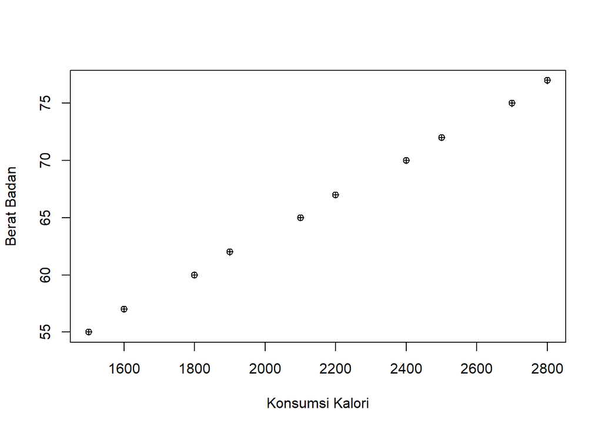

```r
plot(data_1$x, data_1$y, xlab="Konsumsi Kalori", ylab="Berat Badan", pch=10)
```

## a. Tentukan persamaan regresi dugaan beserta maknanya baik dengan perhitungan notasi sigma dan dengan menggunakan R

```r
# Menghitung regresi linear
model1 <- lm(y ~ x, data = data_1)
model1
```

```
##
## Call:
## lm(formula = y ~ x, data = data_1)
##
## Coefficients:
## (Intercept)            x
##    30.06849      0.01671
```

```r
summary(model1)
```

```
##
## Call:
## lm(formula = y ~ x, data = data_1)
##
## Residuals:
##     Min      1Q  Median      3Q     Max
## -0.1918 -0.1610  0.0000  0.1610  0.1918
##
## Coefficients:
##              Estimate Std. Error t value Pr(>|t|)
## (Intercept) 30.068493   0.300278   100.1 1.10e-13 ***
## x            0.016712   0.000137   122.0 2.28e-14 ***
## ---
## Signif. codes:  0 '***' 0.001 '**' 0.01 '*' 0.05 '.' 0.1 ' ' 1
##
## Residual standard error: 0.1851 on 8 degrees of freedom
## Multiple R-squared:  0.9995, Adjusted R-squared:  0.9994
## F-statistic: 1.488e+04 on 1 and 8 DF,  p-value: 2.278e-14
```

Persamaan Regresi Dugaan:

$\hat{y} = \hat{\beta}_0 + \hat{\beta}_1x$

Makna Koefisien:

- $\hat{\beta}_0 = 30.06849$: Ini adalah estimasi nilai y ketika x = 0. Dalam konteks ini, jika konsumsi kalori adalah nol, berat badan diperkirakan akan sekitar 30.06849 kg. Namun, perlu diingat bahwa interpretasi ini mungkin tidak memiliki makna yang nyata karena biasanya konsumsi kalori tidak akan nol.
- $\hat{\beta}_1 = 0.016712$: Ini menunjukkan perubahan rata-rata dalam berat badan y untuk setiap peningkatan satu satuan dalam konsumsi kalori x. Dalam hal ini, setiap peningkatan satu unit dalam konsumsi kalori diperkirakan akan meningkatkan berat badan sebesar 0.016712 kg.

```r
# Menghitung selang kepercayaan 90%
confint(model1)
```

```
##                   2.5 %      97.5 %
## (Intercept) 29.37605033 30.76093597
## x            0.01639644  0.01702822
```

# 2. Lihat kembali soal nomor 1 dan lakukan pengujian asumsi regresi linier sederhana dengan menggunakan grafik dan pengujian hipotesis serta berikan penjelasan.

### Grafik Residual

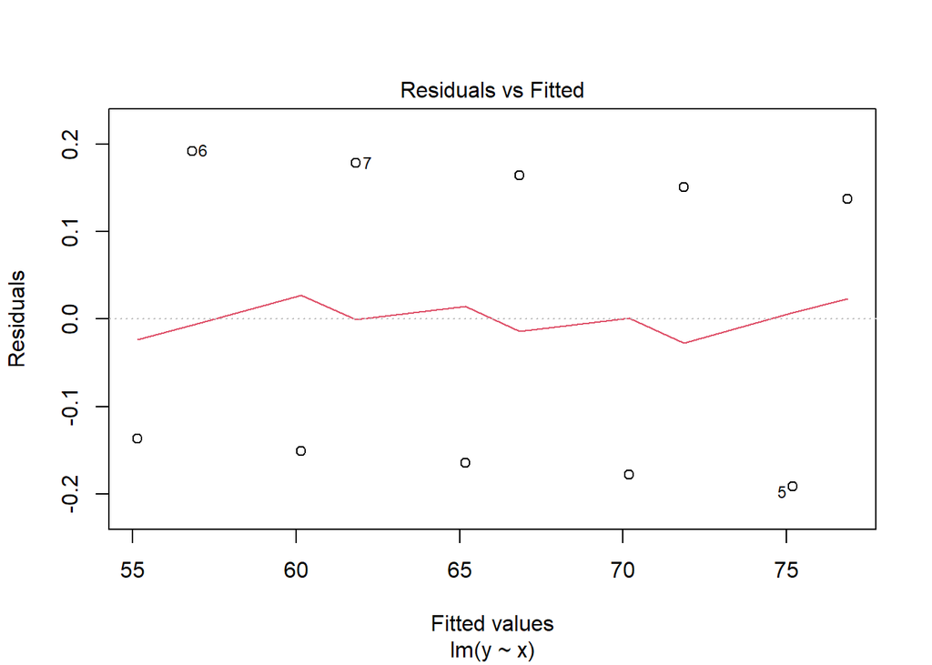

```r
# Plot residual vs fitted values
plot(model1, which = 1)
```

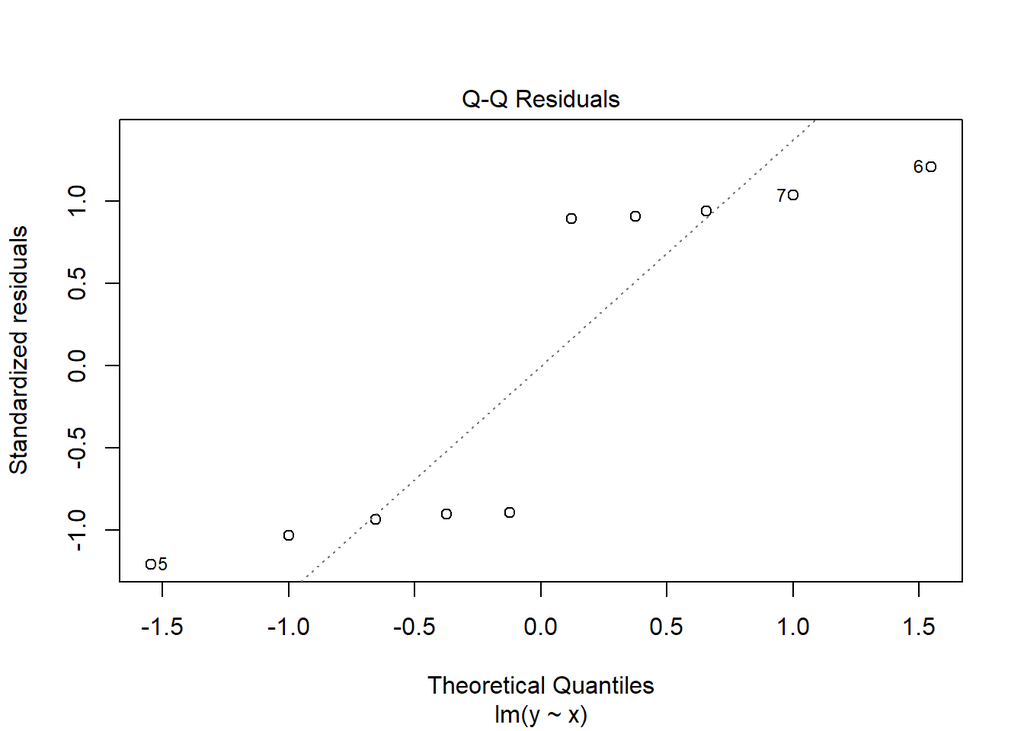

```r
# Plot normal Q-Q plot
plot(model1, which = 2)
```

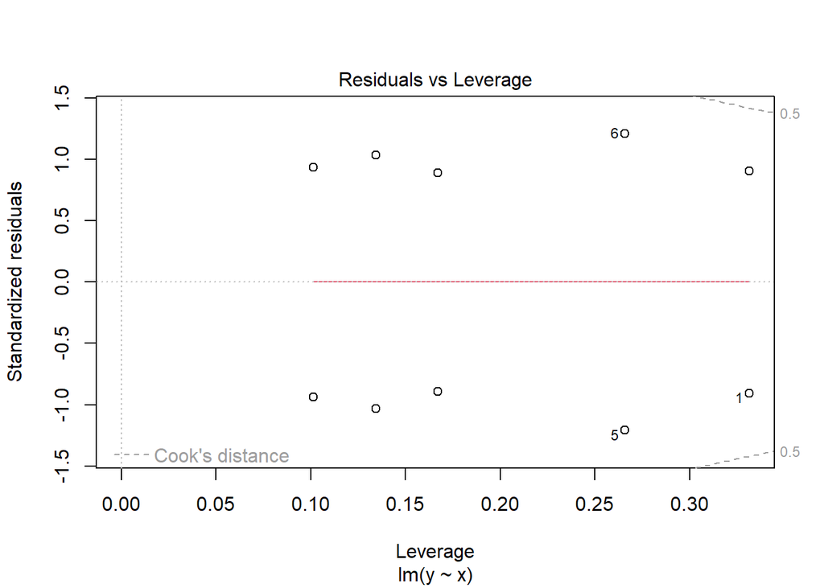

```r
# Plot residual vs leverage
plot(model1, which = 5)
```

### Pengujian Hipotesis

```r
# Uji heteroskedastisitas menggunakan Breusch-Pagan test
library(lmtest)
bptest(model1)
```

```
##
##  studentized Breusch-Pagan test
##
## data:  model1
## BP = 2.5285e-25, df = 1, p-value = 1
```

```r
# Uji normalitas residual menggunakan uji Kolmogorov-Smirnov
shapiro.test(residuals(model1))
```

```
##
##  Shapiro-Wilk normality test
##
## data:  residuals(model1)
## W = 0.75791, p-value = 0.004455
```

**Uji Breusch-Pagan (Heteroskedastisitas):**

**Uji Shapiro-Wilk (Normalitas Residual):**

Hasil uji menunjukkan nilai p-value sekitar 0.004, yang kurang dari tingkat signifikansi 0.05. Oleh karena itu, kita menolak hipotesis nol. Ini menunjukkan bahwa residual tidak terdistribusi secara normal. Hal ini menunjukkan bahwa model mungkin tidak memenuhi asumsi normalitas residual.

# 3. Suatu penelitian dilakukan untuk menyelidiki pengaruh kemampuan konsumsi kalori (X1), jumlah langkah (X2)terhadap prestasi Kadar kolesterol (Y). Data diambil dari 10 wanita berusia 25 tahun. Hasil ANOVA sebagai berikut

```
Analysis of Variance Table
Response: Kadar_Kolesterol_y
 Df Sum Sq Mean Sq F value Pr(>F)
Konsumsi_Kalori_x1 1 562.85 562.85 6566.591 1.147e-11 ***
Jumlah_Langkah_x2 1 … … 16.909 0.004504 **
Residuals 7 0.60 …
Total … 564.90
---
Signif. codes: 0 ‘***’ 0.001 ‘**’ 0.01 ‘*’ 0.05 ‘.’ 0.1 ‘ ’ 1
```

Dan hasil uji t sebagai berikut,

```
Call:
lm(formula = Kadar_Kolesterol_y ~ Konsumsi_Kalori_x1 + Jumlah_Langkah_x2,
 data = toluca)
Residuals:
 Min 1Q Median 3Q Max
 -0.3 -0.2 0.0 0.1 0.4
Coefficients:
 Estimate Std. Error t value
(Intercept) 124.600000 7.066622 17.632
Konsumsi_Kalori_x1 -0.001500 0.004641 -0.323
Jumlah_Langkah_x2 0.011500 0.002797 4.112
---
Residual standard error: 0.2928 on 7 degrees of freedom
Multiple R-squared: 0.9989,
F-statistic: 3292 on 2 and 7 DF, p-value: 3.905e-11
```

## a. Lengkapi tabel ANOVA tersebut.

```
##                  Df    Sum Sq   Mean Sq    F value   Pr(>F)

## Konsumsi_Kalori_x1 1   562.85    562.85    6566.591  1.147e-11 ***

## Jumlah_Langkah_x2  1   1.45      1.45      16.909     0.004504 **

## Residuals          7   0.60      0.0.086

## Total              9   564.90
```

## b. Tentukan persamaan regresi dugaan.

Persamaan regresi dugaan untuk model regresi linear yang melibatkan dua variabel prediktor adalah:

$$Y = \beta_0 + \beta_1 X_1 + \beta_2 X_2
+ \epsilon$$

Dari hasil uji t, kita memiliki estimasi koefisien regresi sebagai berikut: - $\hat{\beta}_0 = 124.6$ - $\hat{\beta}_1 = -0.0015$ - $\hat{\beta}_2 = 0.0115$

Sehingga, persamaan regresi dugaan adalah:

$$Kadar\_Kolesterol\_y = 124.6 - 0.0015
\times Konsumsi\_Kalori\_x1 + 0.0115 \times Jumlah\_Langkah\_x2 +
\epsilon$$

## c. Bila dianggap asumsi-asumsi dalam analisis regresi linear terpenuhi,

### ii. Ujilah apakah ada hubungan linear antara pengaruh konsumsi kalori (X1), jumlah langkah (X2) terhadap prestasi Kadar kolesterol (Y)? Gunakan α = 0.05

Dengan nilai p-value yang sangat kecil ($3.905 \times 10^{-11}$), kita dapat mengkonfirmasi bahwa ada hubungan linear yang signifikan antara Konsumsi Kalori ($X_1$), Jumlah Langkah ($X_2$), dan Kadar Kolesterol ($Y$).

## d. Tentukan koefisien determinasi dan koefisien korelasinya

**Koefisien Determinasi:**

$R^2$: 0.9989

**Koefisien Korelasi:**

$r = \sqrt{R^2} = \sqrt{0.9989} \approx 0.9994$

Ini menunjukkan bahwa ada korelasi yang sangat kuat antara variabel independen dan dependen dalam model regresi.